# Data Science Project - Milestone Report

S Nenning

9 December 2018

## Synopsis

This is the milestone report for the Data Science Spezialiation Capstone project **‘Developing a Data Product for Predictive Text’**.  
This doucment is published on **rpubs.com** http://rpubs.com and contains:  
- data load and exploratory analysis of the data set showing high level summary  
- data cleansing in preparation of text mining  
- initial text mining (n-gram analysis) and plotting of most frequent terms, and  
- an outlook of developing data product with prediction algorithm and Shiny app.

## Data Exploratory Analysis

The data set for building the data product is downloaded from the provided location Capstone Dataset, saved and extracted in working directory. The data set contains blogs, twitter, and news text in English, German, Russian and Finnish.

### Loading data set

Firstly, the required **R packages** are loaded. Package **tm** and **RWeka** is used for text mining.

```r
#loading libaries used in code
library(stringr)
library(tm)
```

```r
library(RWeka)
library(ggplot2)
```

The code below is to load English (en_US) data to R for exporatory analysis.

```r
#define connections and read lines
con_blogs <- file("en_US.blogs.txt", "r")
con_twitter <- file("en_US.twitter.txt", "r")
con_news <- file("en_US.news.txt", "r")
blog <- readLines(con_blogs, skipNul = TRUE)
twitter <- readLines(con_twitter, skipNul = TRUE)
news <- readLines(con_news, skipNul = TRUE)

#close connections
close(con_blogs)
close(con_twitter)
close(con_news)
```

### Word and line count of data set

As the first step of the data exploration, the number of lines and and word count of the loaded data is analysed. The calculated parameters *count_words* and *count_lines* are stored in a dataframe. The loaded text is assigned to a list and a function used for computing the word count.

```r
#store parameters in datafreame; define df with source, line count, word count
df <- data.frame(text_source = c("blog", "twitter", "news"), count_lines = NA, count_words = NA)
#put text into a list
list_text <- list(blog = blog, twitter = twitter, news = news)
#use function to get word count for texts
f_count_word <- function(list_text) { sum(str_count(list_text, "\\S+")) }
# get line count and word count for each text
df$count_lines <- sapply(list_text, length)
df$count_words <- sapply(list_text, f_count_word)
#display table with parameter count
noquote(df)
```

```
##   text_source count_lines count_words
## 1        blog      899288    37334441
## 2     twitter     2360148    30373832
## 3        news     1010242    34372597
```

### Preprocessing of data

The data set has >30 millions words for blogs, news, and twitter text each. I reduce the data to a 5 percent random sample for the text mining exercise.

```r
set.seed(175)
percent <- 0.05
l_sample <- lapply(list_text, function (x) rbinom(x, 1, percent))
# create a empty list
list_sample <- list(blog = NA, twitter = NA, news = NA)
# create sample list from original list
for (i in 1:length(list_text)) {
  list_sample[[i]] <- list_text[[i]][l_sample[[i]] == 1]
}

df_sample <- data.frame(text_source = c("blog", "twitter", "news"), count_lines = NA, count_words = NA)
df_sample$count_lines <- sapply(list_sample, length)
df_sample$count_words <- sapply(list_sample, f_count_word)
noquote(df_sample)
```

```
##   text_source count_lines count_words
## 1        blog       44691     1861422
## 2     twitter      118678     1522280
## 3        news       50454     1727404
```

### Data cleansing

I’m using tm package for creating a text corpus from the sample data and its cleansing. HashTags, Url links, numbers, punctation, stopswords etc are removed. The data cleansing will be further reviewed for final project.

```r
### create corpus classs
corpus_text <- VCorpus(VectorSource(list_sample))

removeURL <- function(x) gsub("http:[[:alnum:]]*", "", x)
removeHashTags <- function(x) gsub("#\\S+", "", x)
removeTwitterHandles <- function(x) gsub("@\\S+", "", x)

# transformations for cleansing

 corpus_text_clean <- tm_map(corpus_text, content_transformer(removeURL))
 corpus_text_clean <- tm_map(corpus_text_clean, content_transformer(removeHashTags))
 corpus_text_clean <- tm_map(corpus_text_clean, content_transformer(removeTwitterHandles))

 corpus_text_clean <- tm_map(corpus_text_clean, content_transformer(tolower))
 corpus_text_clean <- tm_map(corpus_text_clean, content_transformer(removeNumbers))
 corpus_text_clean <- tm_map(corpus_text_clean, content_transformer(removePunctuation))
 corpus_text_clean <- tm_map(corpus_text_clean, content_transformer(stripWhitespace))
 corpus_text_clean <- tm_map(corpus_text_clean, removeWords, stopwords("english"))
```

### Analysis of n-grams

Predictive text is build on n-grams; a consecutive sequence of words. I am creating n-grams in a format of *DocumentTermMatrix* using **RWeka** and **tm** package.  
n-grams for 1 word (unigram), 2 consecutive words (bigram),and 3 consecutive words (trigram) are created.

```r
# tokenize into n-grams
UnigramTokenizer <- function(x) {RWeka::NGramTokenizer(x, RWeka::Weka_control(min = 1, max = 1))}
BigramTokenizer <- function(x) {RWeka::NGramTokenizer(x, RWeka::Weka_control(min = 2, max = 2))}
TrigramTokenizer <- function(x) {RWeka::NGramTokenizer(x, RWeka::Weka_control(min = 3, max = 3))}

#creating uni-grams
unigram_DTM <- tm::DocumentTermMatrix(corpus_text_clean, control = list(tokenize = UnigramTokenizer))

#bi-grams
bigram_DTM <- tm::DocumentTermMatrix(corpus_text_clean, control = list(tokenize = BigramTokenizer))

#tri-grams
trigram_DTM <- tm::DocumentTermMatrix(corpus_text_clean, control = list(tokenize = TrigramTokenizer))
```

As a next steps, the n-grams are put into dataframes with the n-gram terms most frequent in the sample text plotted (top 10)

```r
# put into data frame

#create data frame for uni-grams
unigram_DTM <- sort(colSums(as.matrix(unigram_DTM)),decreasing = TRUE)
df_unigram_DTM <- data.frame(word = names(unigram_DTM), frequency = unigram_DTM)
#head(df_unigram_DTM, 10)

#create data frame for bi-grams
bigram_DTM <- sort(colSums(as.matrix(bigram_DTM)),decreasing = TRUE)
df_bigram_DTM <- data.frame(word = names(bigram_DTM), frequency = bigram_DTM)
#head(df_bigram_DTM, 10)

#create data frame for tri-grams
trigram_DTM <- sort(colSums(as.matrix(trigram_DTM)),decreasing = TRUE)
df_trigram_DTM <- data.frame(word = names(trigram_DTM), frequency = trigram_DTM)
#head(df_trigram_DTM, 10)
```

### Plotting n-gram

Please find below plots for the most frequent n-grams.

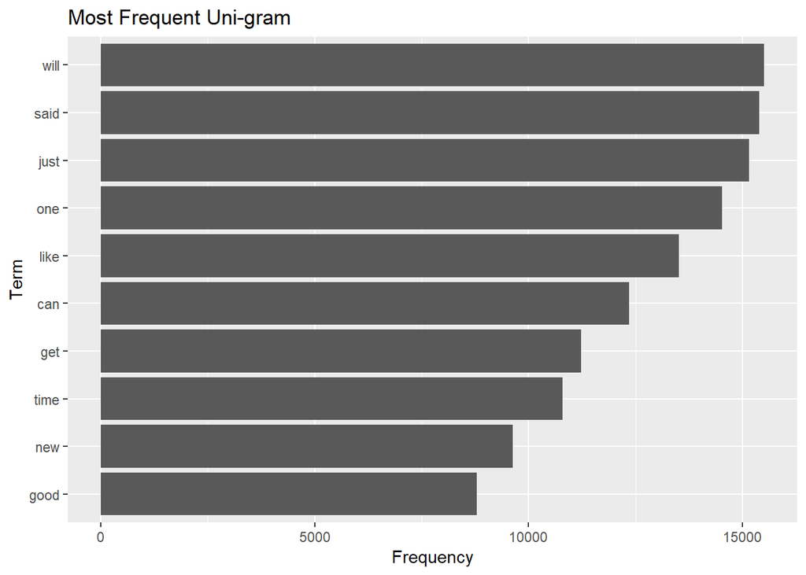

```r
library(ggplot2)
n <-10
# Plot for uni-gram
df_unigram_top <-  head(df_unigram_DTM, n)

g_unigram_top <- ggplot(df_unigram_top, aes(x = reorder(word,frequency), y = frequency))
g_unigram_top <- g_unigram_top + geom_bar(stat = "identity") +coord_flip()  + xlab("Term") + ylab("Frequency") + labs(title = "Most Frequent Uni-gram")
g_unigram_top
```

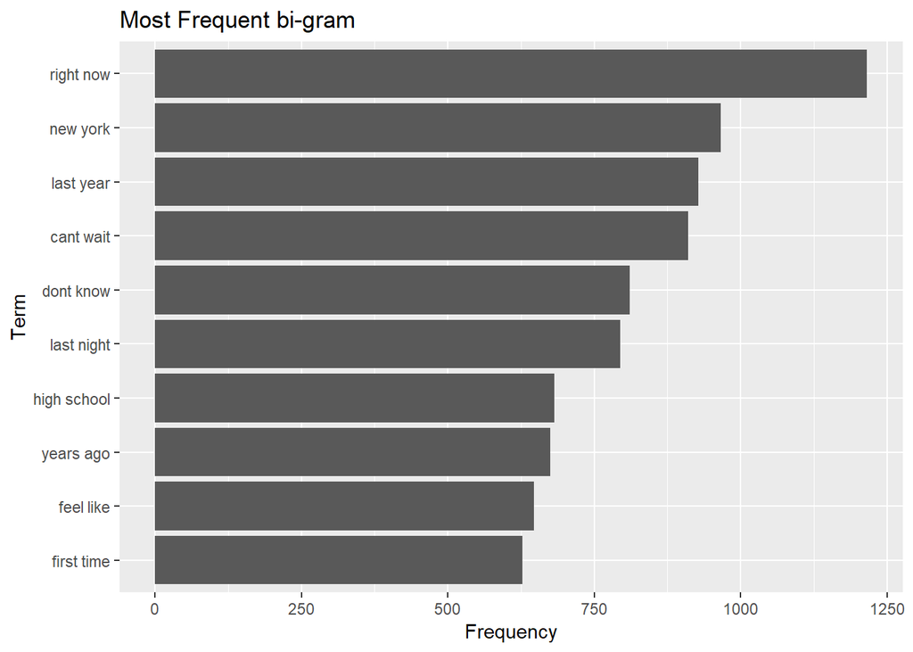

```r
# Plot for bi-gram
df_bigram_top <-  head(df_bigram_DTM, n)

g_bigram_top <- ggplot(df_bigram_top, aes(x = reorder(word,frequency), y = frequency))
g_bigram_top <- g_bigram_top + geom_bar(stat = "identity") +coord_flip()  + xlab("Term") + ylab("Frequency") + labs(title = "Most Frequent bi-gram")
g_bigram_top
```

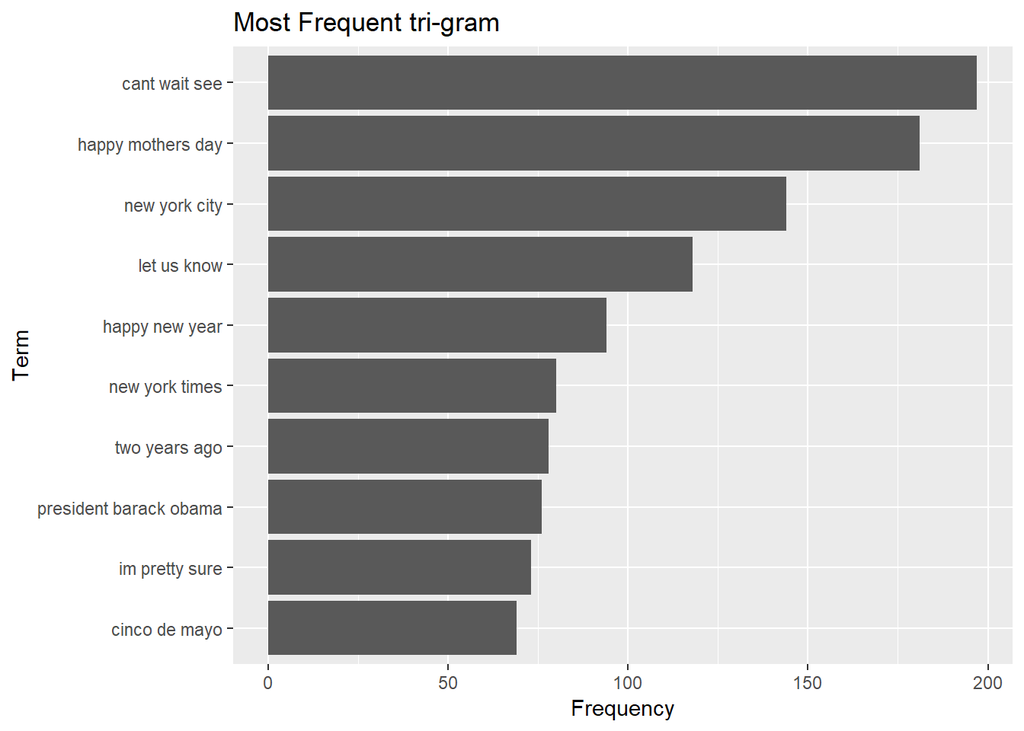

```r
# Plot for tri-gram
df_trigram_top <-  head(df_trigram_DTM, n)

g_trigram_top <- ggplot(df_trigram_top, aes(x = reorder(word,frequency), y = frequency))
g_trigram_top <- g_trigram_top + geom_bar(stat = "identity") +coord_flip()  + xlab("Term") + ylab("Frequency") + labs(title = "Most Frequent tri-gram")
g_trigram_top
```

## Outlook for predictive text data product development

The developed data product will have n-gram directories and a user interface allowing to enter text. After text is entered, the most likely next word options are displayed based on rules like.  
- last 2 words are used to predict next word using tri-gram directory  
- if no tri-gram found with matching first 2 words then last word used get next word from bi-gram directory.  
- if none found, then display most frequent unigram.